# Construct-dependent visibility of Catholic social teaching

Detected markers in Croatia’s Catholic-topic digital-media corpus, 1 January 2021–11 June 2026

Autori

[Luka Šikić](https://www.lukasikic.info/), [Petra Palić](https://www.unicath.hr/odjeli-i-fakultet/nastavnici/petra-palic)

Hrvatsko katoličko sveučilište

## Abstract (English)

How visible is explicit Catholic social teaching (CST) vocabulary in economic discussion inside Croatia’s Catholic-topic digital-media corpus? We analyse 413 985 posts dated 1 January 2021–11 June 2026. A same-domain proximity rule yields 79 439 religion–economy pairs; 1 290 contain an adjacent Tier-1 CST marker (1,62%). Fresh blind Codex audits make that detected-marker rate conditional: post-level invocation precision is 79,6%, below the 80% reporting threshold, and the domain-level economic-referent gate fails or is unevaluable. Climate and energy leads at 12,96% and in all 25 fixed-lexicon specifications, but macroeconomics leads when *Laudato si’* is removed (3,66% vs 3,01%) or ecology markers are removed together (3,56% vs 1,73%). Outlet comparisons and legacy register coding are exploratory. The result is construct-dependent visibility, not corrected prevalence or editorial causation.

**Keywords:** Catholic social teaching; economic discussion; digital media; public religion; measurement; Croatia

## Sažetak (hrvatski)

Koliko je izričit rječnik socijalnoga nauka Crkve (SNC) vidljiv u gospodarskim raspravama unutar hrvatskoga korpusa digitalnih medija odabranoga prema katoličkim temama? Analiziramo 413 985 objava od 1. siječnja 2021. do 11. lipnja 2026. Pravilo blizine unutar iste teme nalazi 79 439 parova religije i gospodarstva; 1 290 sadržava susjednu oznaku SNC-a (1,62%). Svježe slijepe provjere u Codexu uvjetuju taj rezultat: preciznost uporabe nauka na razini objave iznosi 79,6%, ispod praga od 80%, a tematski prag gospodarskoga referenta ne prolazi ili se ne može ocijeniti. Klima i energija vode s 12,96% u svih 25 provjera uz isti leksikon, ali makroekonomija preuzima vodstvo bez *Laudato si’* (3,66% prema 3,01%) i bez ekoloških oznaka zajedno (3,56% prema 1,73%). Rezultat pokazuje ovisnost vidljivosti o konstruktu, a ne ispravljenu prevalenciju ni uredničku uzročnost.

**Ključne riječi:** socijalni nauk Crkve; gospodarska rasprava; digitalni mediji; javna religija; mjerenje; Hrvatska

## 1. Introduction

This journal has examined what Catholic social teaching contributes to Croatian social policy, the Church, solidarity, subsidiarity, social work and the third sector (Valković, 1994, 1996; Šagi, 1995; Zrinščak, 1995; Anić, 1997; Šarić, 1997; Baloban, 2005). We ask an empirical companion question: when economic subjects appear in Croatian Catholic-topic digital media, how often is the teaching named explicitly, and which parts become visible?

Church and Caritas organisations can complement public welfare, while Croatian surveys record concern about inequality and support for redistribution (Kallunki & Zrinščak, 2021; Šućur, 2021). Neither fact establishes whether published economic discussion names CST. Institutional action, attitudes and explicit doctrinal reference are different objects.

We study detectable CST naming, not every compatible argument. A title or doctrine-specific expression must appear within 220 characters of the same economic subject; generic terms such as solidarity do not count. The estimand is a **detected-marker rate** conditional on a topic-selected corpus and deterministic lexicon, not the prevalence of Catholic ideas in Croatian public discourse.

The corrected procedure identifies 1 290 marked pairs among 79 439 religion–economy pairs (1,62%). Climate leads macroeconomics, 12,96% to 4,85%, in 25 fixed-lexicon specifications. The order reverses without *Laudato si’* (3,01% to 3,66%) and without the three ecology markers together (1,73% to 3,56%). The gradient is therefore chiefly about ecology-specific labels, not topic preference across CST as a whole.

Fresh blind model audits impose further limits: post-level genuine invocation is 79,6%, below the 80% threshold; the domain economic-referent gate fails or is incomplete; and its repeat axis misses the agreement threshold. We report the census ratio and assumption-bound denominator sensitivities, but no fully adjusted pair prevalence.

The design makes admission and marker adjacency domain-consistent, separates corpus robustness from lexicon sensitivity, and keeps proposal-based outlet and legacy-register results exploratory.

## 2. Catholic social teaching as a public repertoire

### 2.1 A tradition with several public labels

Modern Catholic social teaching is conventionally traced to *Rerum Novarum* (Leo XIII, 1891). It addresses labour, wages, association, property, poverty and public authority. *Quadragesimo Anno* (Pius XI, 1931), *Laborem Exercens* (John Paul II, 1981) and *Centesimus Annus* (John Paul II, 1991) are prominent in its labour-and-capital line. The *Compendium* relates dignity, the common good, subsidiarity and solidarity to charity, justice, social initiative and public responsibility (Pontifical Council for Justice and Peace, 2004).

*Laudato si’* made integral ecology central and supplied an unusually recognisable title (Francis, 2015); *Fratelli tutti* addressed fraternity and property (Francis, 2020), and *Laudate Deum* renewed the climate intervention (Francis, 2023). Such titles are observable public labels, but create a construct risk: one distinctive name may make its topic look more doctrinally visible than topics expressed without document names.

The analysis accordingly separates two vocabularies. Tier 1 contains sixteen document titles and seven doctrine-specific markers, such as *socijalni nauk*, *supsidijarnost*, *integralna ekologija* and *opcija za siromašne*. Tier 2 contains common political expressions, including solidarity, the common good, social justice and dignity of work. Tier 2 is reported only as an upper boundary on lexical presence because these expressions have ordinary secular uses. It never enters the detected-marker numerator.

This operationalisation does not oppose charity to rights. Catholic teaching itself does not sustain such a simple opposition, and the available legacy codebook does not measure legal entitlements or a language of rights. Historical work on the religious roots of poor relief can motivate questions about institutional repertoires (Kahl, 2005; van Kersbergen & Manow, 2009), but it cannot determine the register of contemporary Croatian digital media.

### 2.2 Public religion, translation and descriptive expectations

Casanova’s account of deprivatised religion locates religious institutions and arguments within modern public life (Casanova, 1994). Habermas distinguishes circulation in an informal public sphere from the translation demands that arise at institutional thresholds (Habermas, 2006). Neither account by itself predicts what Croatian editors publish. Translation is therefore used here as a descriptive heuristic, not a newsroom mechanism.

A recognisable label may attach to an available issue frame. Coverage of *Laudato si’* in US and UK newspapers often foregrounded political rather than religious dimensions (Pou-Amérigo, 2018). This event-centred evidence does not establish a general selection process, but suggests why an encyclical with a distinctive environmental identity may be unusually detectable.

A historical-depth expectation favours labour, wages, business or poverty; a label-availability expectation favours a topic with a salient, readily named document. We cannot distinguish audience demand, source strategy, syndication, editorial choice or document salience, but can test whether domain composition depends on selected labels.

The research questions are therefore:

1. What share of detected religion–economy post–subject pairs contains a same-domain adjacent Tier-1 marker?
2. How does that detected-marker rate vary across eleven economic subjects?
3. How much of the domain ordering survives changes in the corpus specification, the religion-entry frame and the Tier-1 lexicon?
4. How are adjacent document-title sets distributed across subjects, and what do proposal-based outlet groups show descriptively?
5. What limited information can the retained legacy register set contribute without being treated as a prevalence sample?

## 3. Data and methods

### 3.1 The official DigiKat corpus

The input is the official DigiKat database of 413 985 Croatian digital-media posts dated from 1 January 2021 through 11 June 2026. The database contains nine platforms; 286 662 records are web pages, with the remainder coming mainly from Facebook and YouTube and smaller platform collections. DigiKat is a Catholic-topic corpus, not a probability sample of all Croatian news or public expression. Its published documentation describes a 119-term first-pass Catholic-content rule applied to the first 3 000 characters and a second-pass ensemble threshold of 0,70 (DigiKat Project, 2026). All interpretations in this paper are conditional on that selection system.

The run is pinned to SHA-256 `15473a615bf301c02b5d4149d662a4db282927d3b3e98308c5ff54cbe1de520a`. Stable row identifiers, URL, date and text were checked before downstream reconstruction. The official database ends on 11 June 2026, so “2021–2026” never denotes a complete 2026 calendar year.

The collection instrument changes in 2024, and the source feed contains no usable text from February through May of that year. Applying one inclusion rule makes records rule-comparable; it does not make collection periods capture-comparable. We therefore analyse aggregate composition and stream-specific sensitivity, not temporal growth or decline.

### 3.2 Three nested populations and same-domain adjacency

The first stage identifies eleven economic subjects: business and firms; demography and labour supply; the euro changeover; climate and energy; housing; inflation and prices; macroeconomics; poverty and social policy; taxes and fiscal policy; unemployment; and wages and income. A unique post–subject pair enters the main religion–economy frame when a generic religion term falls within 220 characters of an expression from that economic subject. This independent gate yields 66 374 posts and 79 439 pairs. A post may enter several subjects, so the primary analytical unit is the pair.

The Tier-1 marker search is then applied without allowing Tier 1 itself to satisfy the generic-religion gate. A pair enters the core only when at least one Tier-1 span lies within 220 characters of an economic expression **from the same subject that defined the pair**. This corrects a consequential earlier implementation in which adjacency to any economic term at post level could be assigned to all of the post’s Stage-A subjects. The corrected core contains 1 093 posts and 1 290 unique pairs.

The independent Stage-A gate avoids using Tier 1 to create both frame entry and numerator status, but can omit a text in which a document title is the only religious expression. We therefore scan the full corpus under an inclusive alternative. The frame then contains 66 394 posts and 79 500 pairs, while the marked core contains 1 131 posts and 1 351 pairs. It adds 61 marked pairs and 38 marked posts; 20 of those posts were outside the main Stage-A post frame, while the remainder were already linked on another subject. The ordering is unchanged.

#### **Table 1.** The nested official-corpus populations.

| Population | Posts | Post–subject pairs |
| --- | --- | --- |
| Official Catholic-topic corpus | 413 985 | — |
| Main generic-religion Stage-A frame | 66 374 | 79 439 |
| Same-domain adjacent Tier-1 core | 1 093 | 1 290 |
| Inclusive Tier-1-as-religion frame sensitivity | 66 394 | 79 500 |
| Inclusive adjacent Tier-1 core sensitivity | 1 131 | 1 351 |

> Source: authors’ calculation on the official DigiKat corpus of 413 985 Croatian digital media posts, 2021–2026. Stage A requires a generic religion term within 220 characters of an economic expression. Core pairs additionally require a Tier-1 marker within 220 characters of an expression from that same economic subject. The inclusive rows are a frame sensitivity in which Tier 1 may also satisfy religion entry.

The headline estimand for domain $d$ is

$$D_d = \frac{\text{same-domain adjacent Tier-1 pairs in}\, d}
{\text{generic-religion Stage-A pairs in}\, d}.$$

Both counts are a census of the observed official corpus. We therefore report no binomial or Wilson interval around $D_d$. Sampling intervals below describe only the audit samples, conditional on their model classifications.

### 3.3 Fresh blind model audits

Two fresh probability samples assess different parts of the detector. No earlier classification was carried into either main audit.

The R1 numerator audit draws 150 core posts proportionally across the adjacent-term era category (including marker-only and mixed strata) and current outlet-concentration band, with a one-card minimum in small occupied strata and post-stratification to the 1 093-post core. Coders classify whether CST is genuinely invoked, whether the marker is present and whether the nearest adjacent economic expression has a genuine economic referent. The last item is R2. Because R1 is sampled at post level, its precision cannot be multiplied without qualification into pair-level domain rates.

The R4 denominator audit draws a fresh simple random sample of 60 pairs within each domain from the full 79 439-pair Stage-A frame (n = 660). The codebook reading asks whether religious discourse actually takes the detected economic expression as its subject. A strict reading additionally requires an unmistakably economic referent; it excludes cases such as spiritual poverty. The equal domain allocation is reweighted by each domain’s share when an overall layer diagnostic is reported.

Both exercises used fresh-context OpenAI Codex subagents that received only blind batch cards and a bounded codebook. They are model classifications, not human annotations. Main coding was split between two disjoint contexts with no common cards. The service exposed neither the exact backend model identifier nor decoding settings. Stable identifiers were visible and keys existed elsewhere in the restricted workspace, so blinding rests on task isolation. Prompts, restricted outputs and hashes are retained.

R1 had a predeclared 80% genuine-invocation threshold. Its weighted estimate is 79,6% [72,4; 85,3], so the result is **conditional**. Marker presence is 99,3% [96,3; 99,9], the economic-referent result 77,1% [69,7; 83,1], and both jointly 62,8% [54,8; 70,2]. R2 required climate to reach 80% and no sampled domain to fall below 70%. The main-pass nearest-domain diagnostic gives climate 95,5% but taxes 22,6%; euro changeover, demography and inflation receive no card. Because the sample was stratified by adjacent-term era category (including marker-only and mixed strata) and outlet band rather than domain, the formal R2 gate fails where observed and remains incomplete elsewhere.

The R4 layer-weighted codebook and strict classifications are 52,7% and 44,0%. Codebook rates range from 25,0% for wages to 88,3% for climate. Across the two disjoint coder contexts, pooled link classifications are 55,3% and 64,4%, strict classifications 51,2% and 61,2%, R1 invocation 81,2% and 78,6%, and economic-referent classification 85,0% and 68,6%. With no overlapping cards, batch composition cannot be separated from context effects. Climate’s R4 coding is nearly identical across contexts (88,5% and 88,2%) and it remains first in coder-specific denominator sensitivities; lower-domain levels and ordering are less secure.

A separate fresh-context repeat under the same Codex workflow recoded 66 R4 pairs and 30 R1 posts. Agreement is 86,4% (κ = 0,722) for the R4 codebook axis, 84,8% (κ = 0,703) for strict R4 and 93,3% (κ = 0,821) for CST invocation. R1 economic-referent agreement is only 76,7% (κ = 0,420), below 80%. On the six repeated climate cards, the main pass labels five economic referents genuine and the repeat labels none; all seven R2 disagreements switch from main-pass yes to repeat-pass no. Thus even the 95,5% main climate diagnostic is not validated, and the overall repeatability gate fails.

#### **Table 2.** Fresh blind Codex audits and predeclared decision rules.

| Audit quantity | n | Estimate or agreement | Decision |
| --- | --- | --- | --- |
| R1 genuine CST invocation | 150 | 79,6% [72,4; 85,3] | Below 80%; conditional |
| R1 marker present | 150 | 99,3% [96,3; 99,9] | Diagnostic |
| R2 genuine economic referent | 150 | 77,1% [69,7; 83,1] | Domain gate fails/is unevaluable |
| R1 and R2 jointly | 150 | 62,8% [54,8; 70,2] | Diagnostic |
| R4 codebook linkage, layer-weighted | 660 | 52,7% | Denominator sensitivity only |
| R4 strict linkage, layer-weighted | 660 | 44,0% | Denominator sensitivity only |
| Repeat R1 economic-referent axis | 30 | 76,7%; κ = 0,420 | Below 80%; repeatability gate fails |

> Source: authors’ calculation on the official DigiKat corpus of 413 985 Croatian digital media posts, 2021–2026. Fresh probability samples from the corrected official-corpus layers. Brackets are audit-sample intervals conditional on Codex classifications, not uncertainty intervals for census marker rates. R4 contains 60 pairs per subject. The exact backend model version and decoding settings were unavailable.

### 3.4 Sensitivity strategy

The raw census ratio is the identified quantity. For comparability with the audit design, we also calculate a denominator-only sensitivity

$$S_d = \frac{N_{\text{detected},\, d}}
{N_{\text{Stage A},\, d} \times \widehat{p}_d},$$

where $\widehat{p}_d$ is R4 linkage precision. This calculation assumes every detected numerator pair is a genuine link. That assumption is contradicted at the post level by R1 and cannot be verified pair-by-pair because R2 fails or is unevaluable. We therefore call $S_d$ a sensitivity ratio, not corrected or validated prevalence. Conditional Monte Carlo draws propagate the R4 audit-sample classification rate while holding census counts fixed; they do not represent sampling uncertainty in the corpus and do not include model, lexicon or recall uncertainty.

Three other sensitivity families answer distinct questions. First, 25 fixed-lexicon specifications change duplicate handling, title deduplication, foreign-content exclusion, metaphor and Caritas exclusions, collection stream, leading-outlet removal and outlet-group bounds. They ask whether composition alone creates the ranking. Second, an independent frame reconstruction asks what happens when Tier 1 may satisfy religion entry. Third, construct tests remove each Tier-1 term in turn and remove the three ecology-specific markers together. These last tests are essential because corpus robustness cannot compensate for an outcome defined by one unusually topic-specific title.

Outlet groups come from an automated proposal table, not a ratified source registry. We report three deliberately bounded groups: “confessional” for proposed Church-oriented labels, “secular minimum” for explicitly proposed secular labels and “secular maximum” for the latter plus unlabelled sources. These are descriptive association checks. They do not identify a confessional–secular boundary, an editorial decision or a causal translation process.

### 3.5 Pair-specific title categories and the legacy register set

Document categories are assigned separately to each marked post–subject pair from terms adjacent to that subject. This prevents a *Laudato si’* reference near climate from determining the era of another economic subject elsewhere in the same post. The categories are mutually exclusive title sets, not continuous chronological periods. “Non-conciliar classical line” comprises *Rerum Novarum*, *Quadragesimo Anno*, *Laborem Exercens*, *Sollicitudo Rei Socialis* and *Centesimus Annus*. Conciliar and development titles are kept separate even though their publication dates fall inside the broader calendar span. *Caritas in Veritate* forms the Benedict category; Francis-era titles form another category. Pairs carrying only doctrine-specific markers have no era-assigned document, and pairs with titles from more than one set are mixed. The Compendium is treated as a doctrine-specific marker rather than assigned to a papal era.

The final exploratory analysis reuses an earlier 555-row stratified gold set. Of those rows, 296 survive by stable identity in the official database, 268 remain in the corrected linked layer and 148 are classified as genuine links. Table 6 shows only domains with at least ten genuine links, a total of 126. The labels came from three blind passes by one large-language-model family. The original allocation served several validation purposes and is not a probability sample for current register prevalence.

Its categories are “Church as economic actor,” “relief/action,” “structural critique or CST principles” and “devotional/residual.” They do not encode rights, legal entitlement or thematic news framing. We therefore use the set only to delimit what can be inferred and do not reinterpret its categories as charity versus rights.

## 4. Results

### 4.1 The detected-marker rate

The corrected core contains 1 290 marked pairs among 79 439 Stage-A pairs, a detected-marker rate of 1,62%. At post level, 1 093 of 66 374 linked posts are marked, or 1,65%. These two ratios answer different questions: the first weights every post–subject encounter, while the second counts each linked post once.

Because R1 is a post sample, it can illustrate post-level measurement sensitivity without producing a pair estimate. Multiplying the 1,65% post ratio by the 79,6% genuine-invocation estimate gives 1,31%; multiplying by the 62,8% joint R1–R2 estimate gives 1,03%. These are conditional post-level diagnostics, not corrected pair prevalence. The predeclared R1 and R2 rules prevent their promotion to a validated headline.

At pair level, dividing the detected numerator by the layer-weighted R4 denominator classifications gives 3,08% under the codebook reading and 3,69% under the strict reading. Those values are deliberately one-sided: they shrink the denominator while assuming that all 1 290 marked pairs belong in the numerator. They are useful for seeing how denominator contamination could affect scale, but not for claiming that between 3% and 4% of genuine encounters invoke CST.

### 4.2 Domain variation and its dependence on the lexicon

Climate and energy contains 202 marked pairs among 1 559 Stage-A pairs, 12,96%. Macroeconomics is second with 94 of 1 938, or 4,85%. Poverty and social policy supplies the largest number of marked pairs, 586, but its much larger denominator of 31 354 yields a rate of 1,87%. Taxes contributes 208 marked pairs and a rate of 1,47%. No euro-changeover pair carries a same-domain adjacent Tier-1 marker.

The R4 denominator sensitivity leaves climate first: 14,67% under the codebook reading, compared with 7,28% for macroeconomics. Under the strict denominator reading, the corresponding macroeconomic ratio is 7,46%, while climate remains 14,67%. These are not fully adjusted estimates. Their appropriate use is comparative: even a substantial domain-specific deflation of Stage A does not by itself reverse the baseline order.

#### **Table 3.** Detected Tier-1 marker rates and denominator-only sensitivities by economic subject.

| Economic subject | Stage-A pairs | Marked pairs | Detected rate (%) | Denominator-only sensitivity (%) |
| --- | --- | --- | --- | --- |
| Climate and energy | 1 559 | 202 | 12,96 | 14,67 |
| Macroeconomics | 1 938 | 94 | 4,85 | 7,28 |
| Poverty and social policy | 31 354 | 586 | 1,87 | 2,61 |
| Taxes and fiscal policy | 14 110 | 208 | 1,47 | 4,66 |
| Business and firms | 13 143 | 121 | 0,92 | 2,63 |
| Unemployment | 3 335 | 30 | 0,90 | 1,38 |
| Demography and labour supply | 567 | 3 | 0,53 | 0,99 |
| Wages and income | 9 776 | 44 | 0,45 | 1,80 |
| Inflation and prices | 787 | 1 | 0,13 | 0,17 |
| Housing | 2 627 | 1 | 0,04 | 0,05 |
| Euro changeover | 243 | 0 | 0,00 | 0,00 |

> Source: authors’ calculation on the official DigiKat corpus of 413 985 Croatian digital media posts, 2021–2026. The detected rate is a census ratio for the observed corpus and has no sampling interval. The sensitivity divides the detected numerator by an R4-estimated genuine-link denominator and assumes every numerator pair qualifies; because R1/R2 do not pass, it is not corrected prevalence.

#### **Figure 1.** Explicit teaching markers by economic subject.

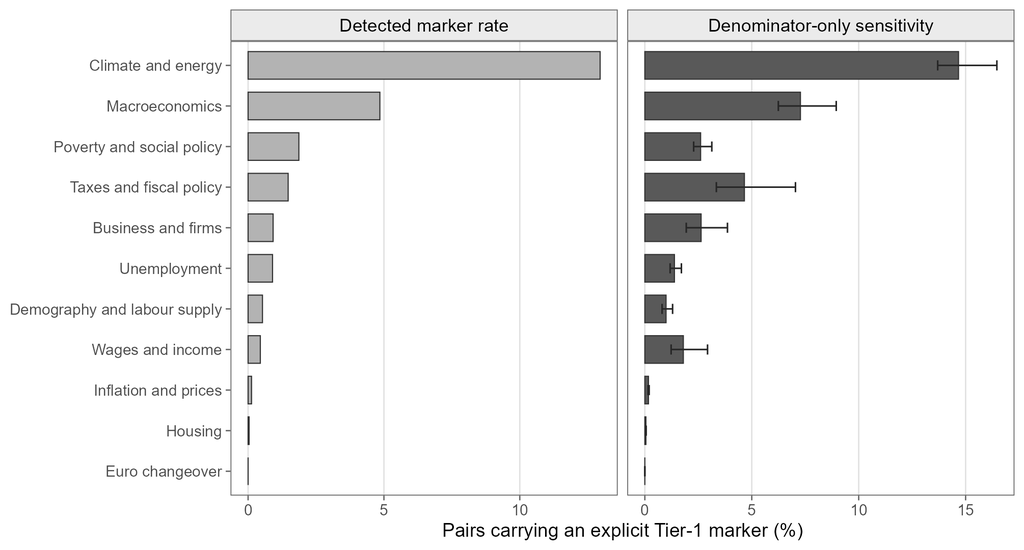

> Source: authors’ calculation on the official DigiKat corpus of 413 985 Croatian digital media posts, 2021–2026. A pair is one post counted on one subject. The left panel is a fixed-corpus detected rate. The right panel divides by model-coded domain precision, 60 fresh pairs per subject, assuming every detected numerator pair qualifies; whiskers propagate audit sampling only.

Figure 1 separates the identified census ratio from the denominator-only calculation. The important comparison is not a confidence test on census counts, but the different effect of R4 denominator precision across subjects.

Holding all 23 Tier-1 terms fixed, climate and energy ranks first in the baseline and in all 24 additional corpus/outlet specifications: 25 of 25 in total. Its raw rate remains 13,28% after near-duplicate-window deduplication, 13,00% after title deduplication, 13,39% after foreign-flagged posts are removed and between 9,57% and 15,43% in the two collection streams. The ranking also survives exclusions for metaphor and Caritas mentions and cumulative removal of the ten largest outlets. This establishes robustness to the tested composition choices under a fixed marker repertoire.

It does not establish robustness to the construct. Removing any individual term other than *Laudato si’* leaves climate first. Removing *Laudato si’* reduces climate to 3,01% and makes macroeconomics first at 3,66%. Removing all three ecology-specific markers (*Laudato si’*, *Laudate Deum* and *integralna ekologija*) reduces climate to 1,73%, while macroeconomics leads at 3,56%. The denominator-only analogues tell the same story: without *Laudato si’*, macroeconomics is first at 5,50% and climate is 3,41%; without all ecology markers, macroeconomics is 5,34% and climate 1,96%.

#### **Figure 4.** The climate lead depends on ecology-specific markers.

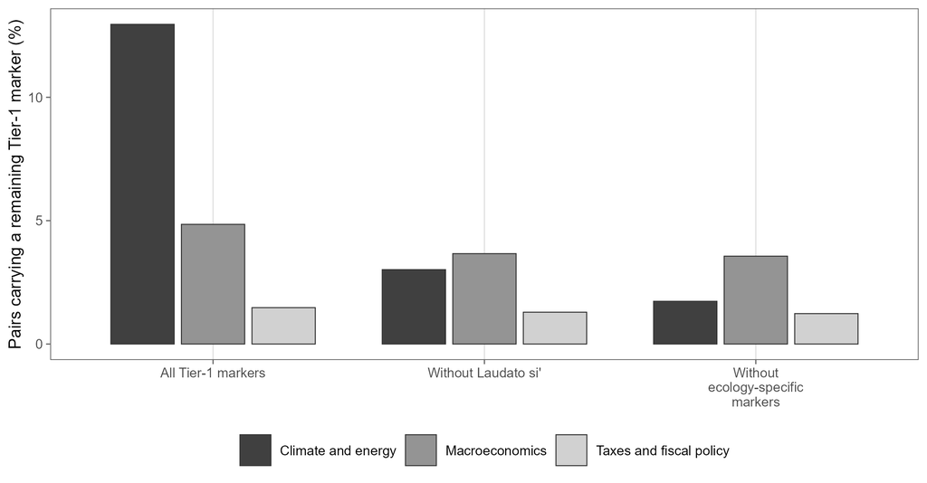

> Source: authors’ calculation. Denominators are fixed. A pair remains when at least one adjacent non-omitted Tier-1 term survives. Removing Laudato si’ reverses the first two subjects.

Figure 4 is therefore the central construct check. The climate lead is real for the predeclared explicit-marker repertoire, but it is carried largely by the visibility of a named ecological document. It should not be paraphrased as greater substantive use of the entire social-teaching tradition in environmental argument.

### 4.3 Pair-specific document categories

Of the 1 290 marked pairs, 705 are assigned Francis as their sole dated-document era for that economic subject; they may also carry undated doctrine-specific markers. Another 416 contain no era-assigned document, 78 are assigned only the non-conciliar classical line, 60 only conciliar/development titles, 10 only *Caritas in Veritate* and 21 titles from more than one set. Because assignment is pair-specific, these counts sum exactly to the pair numerator.

Climate and energy is especially concentrated: 187 of 202 pairs, or 92,6%, are assigned Francis as their sole dated-document era, although they may also carry undated markers; just one pair (0,5%) is assigned only a non-conciliar classical title. The classical-line share is higher for wages and income, 12 of 44 (27,3%), and lower for business and firms, 8 of 121 (6,6%). Poverty combines 344 Francis-assigned pairs, 155 marker-only pairs, 38 conciliar, 32 classical, 12 mixed and five Benedict pairs.

#### **Table 4.** Pair-specific adjacent document-title categories by economic subject.

| Economic subject | Benedict | Non-conciliar classical line | Conciliar/development | Francis era | No era-assigned document | Mixed | Total |
| --- | --- | --- | --- | --- | --- | --- | --- |
| Poverty and social policy | 5 | 32 | 38 | 344 | 155 | 12 | 586 |
| Taxes and fiscal policy | 3 | 8 | 16 | 73 | 106 | 2 | 208 |
| Climate and energy | 0 | 1 | 0 | 187 | 10 | 4 | 202 |
| Business and firms | 0 | 8 | 1 | 44 | 67 | 1 | 121 |
| Macroeconomics | 2 | 13 | 3 | 37 | 38 | 1 | 94 |
| Wages and income | 0 | 12 | 2 | 13 | 16 | 1 | 44 |
| Unemployment | 0 | 3 | 0 | 5 | 22 | 0 | 30 |

> Source: authors’ calculation on the official DigiKat corpus of 413 985 Croatian digital media posts, 2021–2026. Categories are assigned separately for each post–subject pair from its adjacent terms. They are mutually exclusive document-title sets, not contiguous calendar eras; doctrine-specific markers, including the Compendium convention, appear under “No era-assigned document.” Subjects with fewer than ten marked pairs are retained in the aggregate total but omitted from display.

#### **Figure 2.** Adjacent document eras by economic subject.

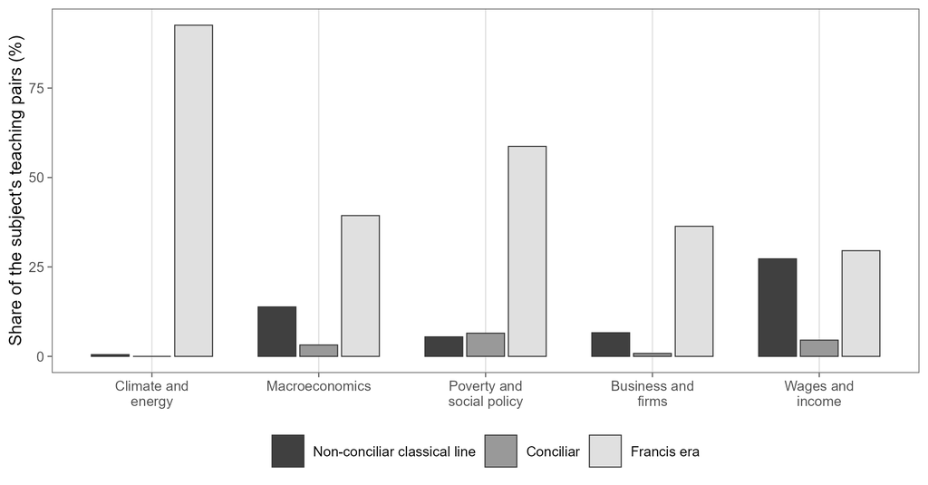

> Source: authors’ calculation. Era is assigned to the Tier-1 term adjacent to each specific post-subject pair. Marker-only, Benedict XVI and mixed-era pairs are reported in Table 4.

Figure 2 makes the composition result visible: the leading environmental row is overwhelmingly tied to Francis-era titles, whereas older economic subjects contain more marker-only and non-conciliar classical references. This pattern is compatible with recency and label availability. It cannot distinguish between them causally.

### 4.4 Proposal-based outlet comparisons

The proposal-labelled confessional group has a climate detected rate of 19,47% and a macroeconomic rate of 11,76%, a ratio of 1,66. Under the narrow secular proposal, the corresponding values are 11,58% and 2,83%, a ratio of 4,09. Under the deliberately broad secular maximum, which assigns unlabelled sources to the secular side, they are 10,86% and 1,91%, a ratio of 5,68.

#### **Table 5.** Proposal-based outlet-group sensitivity for the two leading domains.

| Proposed outlet group | Climate and energy (%) | Macroeconomics (%) | Climate/macro ratio |
| --- | --- | --- | --- |
| Confessional | 19,47 | 11,76 | 1,66 |
| Secular minimum | 11,58 | 2,83 | 4,09 |
| Secular maximum | 10,86 | 1,91 | 5,68 |

> Source: authors’ calculation on the official DigiKat corpus of 413 985 Croatian digital media posts, 2021–2026. Automated, unratified outlet-label proposals. “Secular minimum” includes explicitly proposed secular sources; “secular maximum” also includes unlabelled sources. Values are descriptive detected-marker rates, not causal effects or validated outlet classifications.

#### **Figure 3.** Subject profiles under proposed outlet classifications.

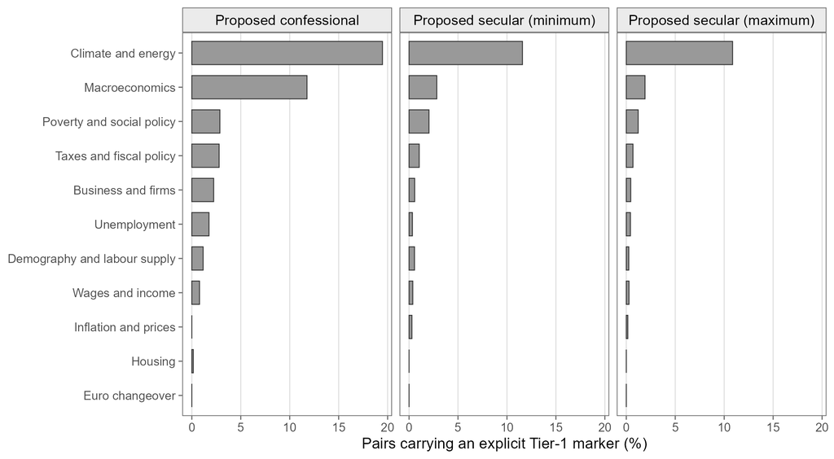

> Source: authors’ calculation. Outlet labels are automated proposals, unratified, and used only as a sensitivity. The secular maximum adds unlabelled and other outlets to the proposed secular group.

The climate-to-macro contrast is flatter in the proposed confessional set and steeper under both secular bounds. This association is consistent with a portable environmental label, but several alternatives remain: outlet mix, source material, syndication, event coverage and label error. Because the groups are proposals and the design is observational, Figure 3 does not demonstrate boundary selection or editorial translation.

### 4.5 What the legacy register set can and cannot show

The 148 genuine links retained from the legacy set are distributed unevenly across subjects. Restricting display to domains with at least ten links leaves 126 cases. Among 77 poverty and social-policy links, 26,0% are coded as relief/action, 19,5% as structural critique or CST principles, 6,5% as the Church acting economically and 48,1% as devotional/residual. Among eleven climate links, all are coded structural/CST-principles; the small, purposefully assembled set does not make that a population estimate.

#### **Table 6.** Exploratory legacy register classifications in domains with at least ten genuine links (%).

| Economic subject | n | Church as economic actor | Relief/action | Structural critique or CST principles | Devotional/residual |
| --- | --- | --- | --- | --- | --- |
| Poverty and social policy | 77 | 6,5 | 26,0 | 19,5 | 48,1 |
| Wages and income | 16 | 56,2 | 25,0 | 12,5 | 6,2 |
| Unemployment | 12 | 25,0 | 16,7 | 58,3 | 0,0 |
| Climate and energy | 11 | 0,0 | 0,0 | 100,0 | 0,0 |
| Demography and labour supply | 10 | 0,0 | 70,0 | 30,0 | 0,0 |

> Source: authors’ calculation on the official DigiKat corpus of 413 985 Croatian digital media posts, 2021–2026. Reanalysis of an earlier 555-row stratified set: 296 survive in the official database, 268 remain in the corrected linked layer, 148 are genuine links and 126 appear in displayed domains with n ≥ 10. Labels came from three blind passes by one LLM family. The allocation was not designed to estimate register prevalence, and the codebook does not measure rights or entitlements.

The large poverty residual and the validation-oriented allocation defeat any claim that poverty coverage is predominantly relief-oriented. The table can motivate a new study, but it cannot adjudicate a charity-versus-rights hypothesis. Such a study would require a fresh probability sample, a codebook that directly measures entitlement and responsibility, and independent human coders.

## 5. Discussion

### 5.1 The substantive result is narrower and more informative than a topic ranking

The rerun does not show that CST generally appears most often in environmental reasoning. It shows that selected explicit markers occur most often in climate pairs in this corpus: stable across composition choices, but not after removing the label most closely bound to environmental teaching.

*Laudato si’* occurs in 341 teaching posts, second only to *socijalni nauk* in 366. These are term–post presences, not quotations or repeated “times.” Its prominence may reflect public labelling, event salience or repeated source material; in every case, it makes one portion of the tradition easier for a literal detector to see.

The older line is comparatively more visible in wages and macroeconomics, but its titles are sparse: *Rerum Novarum* appears in 48 core posts, *Laborem Exercens* in eight and *Quadragesimo Anno* in three. Unlabelled arguments may be more common; the design intentionally does not count them as explicit CST.

Religious traditions do not enter published discussion as undifferentiated systems: some names become portable handles while other arguments circulate without provenance. Quotation roles, publication events and source-to-outlet transmission are needed to explain the pattern causally.

### 5.2 Measurement lessons for social-policy corpus research

First, numerator and denominator must share a unit and domain. Assigning adjacency to any economic word across every subject inflates multi-topic posts; pair-specific same-domain adjacency removes that error.

Second, denominator correction is not rate validation. R4 precision differs by domain, but division by it assumes a perfect numerator where R1 is 79,6% and R2 fails. Multiplying post-level numerator precision by pair-level denominator precision would mix units and errors; fully adjusted pair prevalence remains unidentified.

Third, robustness and construct validity differ. The 25 fixed-lexicon results address outlets, duplicates, streams and exclusions; leave-one-term-out results reveal lexical concentration. Both are required.

Fourth, model annotation needs provenance and stopping rules. The unavailable backend version limits replication; non-overlapping contexts prevent separation of batch and context effects; and the six-card climate reversal shows that “economic referent” is difficult. Human validation is the next step.

### 5.3 Implications for Croatian social-policy research

Institutional welfare activity can matter when doctrinal labels are rare, while frequent naming does not establish policy influence. Future studies should separately examine provision, discourse registers and source-to-outlet transmission. The marker map locates candidate material but answers none of those questions alone.

Responsibility attribution can matter (Iyengar, 1990; Boukes, 2022), but the legacy codebook measures neither episodic/thematic framing nor rights. With nearly half of poverty links residual, a charity-versus-entitlement reading would exceed the data and the teaching’s relation between charity and justice.

## 6. Limitations, reproducibility and research ethics

Seven limitations govern interpretation.

First, the corpus is selected for Catholic topicality. The 1,62% rate applies to detected religion–economy pairs inside the official DigiKat database, not to all Croatian news, all social-media posts or the national public sphere. Platform and outlet composition are not population-representative.

Second, explicit lexical detection sacrifices recall for interpretability. Unlabelled arguments compatible with CST remain outside the numerator. Tier 2 demonstrates that common normative vocabulary is much broader, but treating every generic occurrence as doctrinal would sacrifice specificity.

Third, proximity is not proof of argument, framing or attribution. R1 and R4 show error; R2 fails or is incomplete, and its repeat pass falls below threshold with an extreme climate-subset reversal. No fully adjusted pair prevalence is reported.

Fourth, denominator-only sensitivities rest on an intentionally favourable numerator assumption. Their audit intervals are conditional on a model-labelled sample and do not include model variation, lexicon omissions or corpus-filter error. Census ratios themselves receive no Wilson inference.

Fifth, the climate result is construct-dependent. It is robust to the tested corpus specifications only while the marker repertoire is fixed; it reverses without *Laudato si’* or the ecology-specific group.

Sixth, outlet labels are unratified proposals. The group contrasts are descriptive sensitivity checks and cannot establish a confessional–secular boundary, editorial causation or translation. Duplicate texts may represent real exposure even when they reduce independence.

Seventh, the 2024 collection change and February–May text gap prevent temporal inference. The study describes the composition of material observed between 1 January 2021 and 11 June 2026.

### Data availability and computational reproducibility

Vendor-sourced row-level text, URLs, source identities and coding cards cannot be redistributed. Versioned code, the official input manifest, aggregate audit outputs, tables and figures are available in the DigiKat repository. The run pins the database and intermediate layers by cryptographic hash and checks that the 1 290 pair-specific era assignments reconcile to the core numerator. DigiKat’s public database documentation defines corpus collection and inclusion (DigiKat Project, 2026).

Generative AI was used as a measurement instrument and as assistance in the computational and manuscript workflow. The fresh R1 and R4 annotations and the repeat pass were produced by bounded Codex subagents from blind cards; the legacy register labels came from three blind passes by one LLM family. Exact backend model identifiers and decoding settings were not exposed for the fresh workflow. These classifications are not described as human coding. The authors remain responsible for the design, interpretation, source checking and final text.

### Ethics, funding and competing interests

The study analyses published media material and reports no row-level text or private individuals. No external funding was received specifically for this analysis. The authors declare no competing interests. The DigiKat project is maintained at the Croatian Catholic University; that institutional location is disclosed because the paper evaluates visibility of Catholic social teaching.

## 7. Conclusion

In Croatia’s official Catholic-topic digital-media corpus, 1 290 of 79 439 detected religion–economy post–subject pairs contain an adjacent Tier-1 CST marker from the same economic domain. The observed detected-marker rate is 1,62%. It is the defensible headline because the post-level invocation audit falls just below its 80% threshold, the domain-level economic-referent gate fails or is unevaluable, and one repeatability axis also fails. Denominator-only values of 3,08% and 3,69% are assumption-bound sensitivities, not corrected prevalence.

Climate and energy leads at 12,96% and remains first in all 25 specifications that hold the lexicon fixed. Yet its lead reverses when *Laudato si’* is removed and weakens further when ecology-specific markers are removed together. The principal finding is therefore not environmental dominance of Catholic social teaching. It is the exceptional detectability of a recent ecological label within this corpus.

That conclusion is narrower than a claim about Croatian public debate, but it is analytically useful. It shows where explicit doctrinal names are available, where a literal detector misses less portable traditions, and why corpus robustness must be paired with lexicon sensitivity. It also leaves clear tasks for future work: ratified outlet classification, independent human validation, pair-level numerator auditing and a purpose-built probability sample for poverty, entitlement and responsibility registers.

## References

- Anić, R. (1997). Solidarnost u učenju Ivana Pavla II. *Revija za socijalnu politiku*, 4(4), 349–355. https://doi.org/10.3935/rsp.v4i4.367
- Baloban, S. (2005). Karitativni rad Katoličke Crkve kao ishodište socijalnog rada u Hrvatskoj. *Revija za socijalnu politiku*, 12(3–4), 275–283. https://doi.org/10.3935/rsp.v12i3.84
- Boukes, M. (2022). Episodic and thematic framing effects on the attribution of responsibility: The effects of personalized and contextualized news on perceptions of individual and political responsibility for causing the economic crisis. *The International Journal of Press/Politics*, 27(2), 374–395. https://doi.org/10.1177/1940161220985241
- Casanova, J. (1994). *Public religions in the modern world*. University of Chicago Press.
- DigiKat Project. (2026). *Baza podataka: sadržaj, prikupljanje i pravilo uključivanja*. https://lusiki.github.io/DigiKat/pages/baza.html
- Francis. (2015). *Laudato si’* [Encyclical]. https://www.vatican.va/content/francesco/en/encyclicals/documents/papa-francesco_20150524_enciclica-laudato-si.html
- Francis. (2020). *Fratelli tutti* [Encyclical]. https://www.vatican.va/content/francesco/en/encyclicals/documents/papa-francesco_20201003_enciclica-fratelli-tutti.html
- Francis. (2023). *Laudate Deum* [Apostolic exhortation]. https://www.vatican.va/content/francesco/en/apost_exhortations/documents/20231004-laudate-deum.html
- Habermas, J. (2006). Religion in the public sphere. *European Journal of Philosophy*, 14(1), 1–25. https://doi.org/10.1111/j.1468-0378.2006.00241.x
- Iyengar, S. (1990). Framing responsibility for political issues: The case of poverty. *Political Behavior*, 12(1), 19–40. https://doi.org/10.1007/BF00992330
- John Paul II. (1981). *Laborem Exercens* [Encyclical]. https://www.vatican.va/content/john-paul-ii/en/encyclicals/documents/hf_jp-ii_enc_14091981_laborem-exercens.html
- John Paul II. (1991). *Centesimus Annus* [Encyclical]. https://www.vatican.va/content/john-paul-ii/en/encyclicals/documents/hf_jp-ii_enc_01051991_centesimus-annus.html
- Kahl, S. (2005). The religious roots of modern poverty policy: Catholic, Lutheran and Reformed Protestant traditions compared. *European Journal of Sociology*, 46(1), 91–126. https://doi.org/10.1017/S0003975605000044
- Kallunki, V., & Zrinščak, S. (2021). Interdependence and competition between the religious and the secular: The welfare role of the Church in Croatia and Finland. *Journal of Contemporary Religion*, 36(1), 123–142. https://doi.org/10.1080/13537903.2021.1879446
- Leo XIII. (1891). *Rerum Novarum* [Encyclical]. https://www.vatican.va/content/leo-xiii/en/encyclicals/documents/hf_l-xiii_enc_15051891_rerum-novarum.html
- Pius XI. (1931). *Quadragesimo Anno* [Encyclical]. https://www.vatican.va/content/pius-xi/en/encyclicals/documents/hf_p-xi_enc_19310515_quadragesimo-anno.html
- Pontifical Council for Justice and Peace. (2004). *Compendium of the Social Doctrine of the Church*. https://www.vatican.va/roman_curia/pontifical_councils/justpeace/documents/rc_pc_justpeace_doc_20060526_compendio-dott-soc_en.html
- Pou-Amérigo, M.-J. (2018). Framing ‘Green Pope’ Francis: Newspaper coverage of Encyclical *Laudato Si’* in the United States and the United Kingdom. *Church, Communication and Culture*, 3(2), 136–151. https://doi.org/10.1080/23753234.2018.1478229
- Šagi, B. Z. (1995). Crkva i socijalna politika u našim okolnostima. *Revija za socijalnu politiku*, 2(1), 1–11. https://doi.org/10.3935/rsp.v2i1.542
- Šarić, I. (1997). Solidarnost i supsidijarnost kao temelji socijalnog tržišnog gospodarstva. *Revija za socijalnu politiku*, 4(4), 339–348. https://doi.org/10.3935/rsp.v4i4.366
- Šućur, Z. (2021). Dohodovne nejednakosti i redistributivne preferencije u Hrvatskoj i zemljama EU-a: makroanaliza. *Revija za socijalnu politiku*, 28(2), 133–161. https://doi.org/10.3935/rsp.v28i2.1700
- Valković, M. (1994). Socijalni nauk Crkve i socijalna politika. *Revija za socijalnu politiku*, 1(1), 15–24. https://doi.org/10.3935/rsp.v1i1.614
- Valković, M. (1996). Solidarnost i pravda kao temelj socijalne države. *Revija za socijalnu politiku*, 3(3), 217–238. https://doi.org/10.3935/rsp.v3i3.457
- van Kersbergen, K., & Manow, P. (Eds.). (2009). *Religion, class coalitions, and welfare states*. Cambridge University Press. https://doi.org/10.1017/CBO9780511626784
- Zrinščak, S. (1995). Religija, Crkva i treći sektor u Srednjoj i Istočnoj Europi. *Revija za socijalnu politiku*, 2(4), 305–314. https://doi.org/10.3935/rsp.v2i4.502

## Appendix A. Explicit Tier-1 vocabulary

#### **Table A1.** Tier-1 document titles and doctrine-specific markers at each detection stage.

| Marker | Type | Pair-specific title category | Corpus posts | Stage-A posts | Adjacent term–post presences |
| --- | --- | --- | --- | --- | --- |
| *socijalni nauk* (social teaching) | Doctrine-specific marker | — | 1 582 | 887 | 366 |
| *Laudato si’* | Document title | Francis era | 1 074 | 733 | 341 |
| *Fratelli tutti* | Document title | Francis era | 1 163 | 575 | 164 |
| *Evangelii gaudium* | Document title | Francis era | 655 | 425 | 127 |
| *supsidijarnost* (subsidiarity) | Doctrine-specific marker | — | 297 | 206 | 58 |
| *Rerum novarum* | Document title | Non-conciliar classical line | 334 | 215 | 48 |
| *Gaudium et spes* | Document title | Conciliar/development | 463 | 196 | 44 |
| *opcija za siromašne* (option for the poor) | Doctrine-specific marker | — | 30 | 26 | 26 |
| *integralna ekologija* (integral ecology) | Doctrine-specific marker | — | 106 | 79 | 25 |
| *Laudate Deum* | Document title | Francis era | 88 | 55 | 23 |
| *Populorum progressio* | Document title | Conciliar/development | 61 | 40 | 20 |
| *Caritas in veritate* | Document title | Benedict XVI | 115 | 80 | 17 |
| *Centesimus annus* | Document title | Non-conciliar classical line | 80 | 57 | 16 |
| *Sollicitudo rei socialis* | Document title | Non-conciliar classical line | 23 | 18 | 10 |
| *kompendij socijalnog nauka* (Compendium) | Doctrine-specific marker | — | 66 | 49 | 9 |
| *socijalna doktrina* (social doctrine) | Doctrine-specific marker | — | 26 | 18 | 9 |
| *Laborem exercens* | Document title | Non-conciliar classical line | 34 | 24 | 8 |
| *Pacem in terris* | Document title | Conciliar/development | 139 | 68 | 7 |
| *Dignitas infinita* | Document title | Francis era | 140 | 77 | 6 |
| *Mater et magistra* | Document title | Conciliar/development | 34 | 24 | 5 |
| *univerzalna namjena dobara* (destination of goods) | Doctrine-specific marker | — | 8 | 7 | 4 |
| *Quadragesimo anno* | Document title | Non-conciliar classical line | 27 | 21 | 3 |
| *Octogesima adveniens* | Document title | Conciliar/development | 2 | 1 | 0 |

> Source: authors’ calculation on the official DigiKat corpus of 413 985 Croatian digital media posts, 2021–2026. Entries are numbers of posts carrying each term at the stated stage; the final column comprises 1 336 term–post presences across 1 093 teaching posts because one post may carry several terms. Counts are not numbers of quotations or repeated occurrences. The Compendium is treated as a doctrine-specific marker with no era-assigned document.